# Differential Expression

Michael Steinbaugh

2018-02-20

```r
# Last modified 2018-02-20
bcbioRNASeq::prepareRNASeqTemplate()
source("_setup.R")

# Directory paths
data_dir <- file.path(params$output_dir, "data", Sys.Date())
results_dir <- file.path(params$output_dir, "results", "differential_expression")
invisible(mapply(
    FUN = dir.create,
    list(data_dir, results_dir),
    MoreArgs = list(recursive = TRUE, showWarnings = FALSE)
))

# Load bcbioRNASeq object
bcb_name <- load(params$bcb_file)
bcb <- get(bcb_name, inherits = FALSE)
stopifnot(is(bcb, "bcbioRNASeq"))
invisible(validObject(bcb))
```

# Overview

- Principal Investigator: Kevin Eggan
- Researcher: Joseph Klim
- Experiment: ES-derived motor neuron knockdown RNA-seq

For the differential expression analysis, we used [DESeq2](https://bioconductor.org/packages/release/bioc/html/DESeq2.html) 1.18.1. We employed a design formula (~date + category) that accounts for the date batch effect. For more information on design formulas in [DESeq2](https://bioconductor.org/packages/release/bioc/html/DESeq2.html), run `help("design", "DESeq2")` in [R](https://www.r-project.org).

Here we’re discarding the NoTx samples from the analysis. Note that since these 3 samples have been dropped, the values of the normalized counts will change, since we’re now only looking at 15 samples. I’ve uploaded these updated counts into the `results/` directory.

```r
> dds <- bcbio(bcb, "DESeqDataSet")
> dim(dds)
>
> # Drop the `NoTx_*` samples from the analysis
> keep_samples <- colnames(dds)[which(!is.na(dds$treatment))]
> keep_samples
>
> dds <- selectSamples(dds, sampleID = keep_samples)
> dim(dds)
> colnames(dds)
>
> # Now set the design formula and run DESeq
> design(dds) <- params$design
> dds <- DESeq(dds)
> rld <- rlog(dds)
```

Since the dimensions of the dataset have changed, we need to resave the normalized counts.

```r
> normalized_counts <- counts(dds, normalized = TRUE)
> writeCounts(normalized_counts, dir = file.path("results", "counts"))
> saveData(dds, normalized_counts, rld, dir = data_dir)
```

```r
> dropbox_normalized_counts_resave <- copyToDropbox(c(normalized_counts = file.path("results",
+     "counts", "normalized_counts.csv.gz")), dir = params$dropbox_dir)
```

```
## Dropbox: Michael Steinbaugh (HBC) <msteinbaugh@hsph.harvard.edu>
```

```
## File results/counts/normalized_counts.csv.gz uploaded as /eggan-es_derived_motor_neuron_knockdown-rnaseq-human/normalized_counts.csv.gz successfully at 2018-02-20T17:47:37Z
```

```r
> saveData(dropbox_normalized_counts_resave, dir = data_dir)
```

```
## Saving dropbox_normalized_counts_resave.rda to /mnt/Orchestra/eggan-es_derived_motor_neuron_knockdown-rnaseq-human/data/2018-02-20
```

# Alpha level (FDR) cutoffs

Let’s take a look at the number of genes we get with different false discovery rate (FDR) cutoffs. These tests subset *P* values that have been multiple test corrected using the Benjamini Hochberg (BH) method (Benjamini and Hochberg 1995).

```r
> alphaSummary(dds)
```

|  | 0.1 | 0.05 | 0.01 | 0.001 | 1e-06 |
| --- | --- | --- | --- | --- | --- |
| LFC > 0 (up) | 749, 1.8% | 493, 1.2% | 225, 0.53% | 95, 0.22% | 38, 0.089% |
| LFC < 0 (down) | 607, 1.4% | 392, 0.92% | 177, 0.42% | 69, 0.16% | 25, 0.059% |
| outliers | 67, 0.16% | 67, 0.16% | 67, 0.16% | 67, 0.16% | 67, 0.16% |
| low counts | 24298, 57% | 24298, 57% | 23489, 55% | 23489, 55% | 23489, 55% |
| cutoff | (mean count < 10) | (mean count < 10) | (mean count < 8) | (mean count < 8) | (mean count < 8) |

# Results

```r
> # help('results', 'DESeq2') For contrast argument as character vector: 1.
> # Design matrix factor of interest.  2. Numerator for LFC (expt).  3.
> # Denominator for LFC (control).
> res_unshrunken <- results(dds, contrast = params$contrast, alpha = params$alpha)
>
> # DESeqResults with shrunken log2 fold changes (LFC) help('lfcShrink',
> # 'DESeq2')
> res_shrunken <- lfcShrink(dds = dds, contrast = params$contrast, res = res_unshrunken)
>
> # Use shrunken LFC values by default
> res <- res_shrunken
> saveData(res, res_shrunken, res_unshrunken, dir = data_dir)
```

We performed the analysis using a BH adjusted *P* value cutoff of 0.05 and a log fold-change (LFC) ratio cutoff of 0.

# Plots

We’re seeing a small but consistent effect size. Based on these results, I don’t recommend applying a log fold change cutoff to our list of differentially expressed genes.

## Mean average (MA)

An MA plot compares transformed counts on `M` (log ratio) and `A` (mean average) scales (Y. H. Yang et al. 2002).

```r
> markdownHeader("shrunken", level = 3)
```

### shrunken

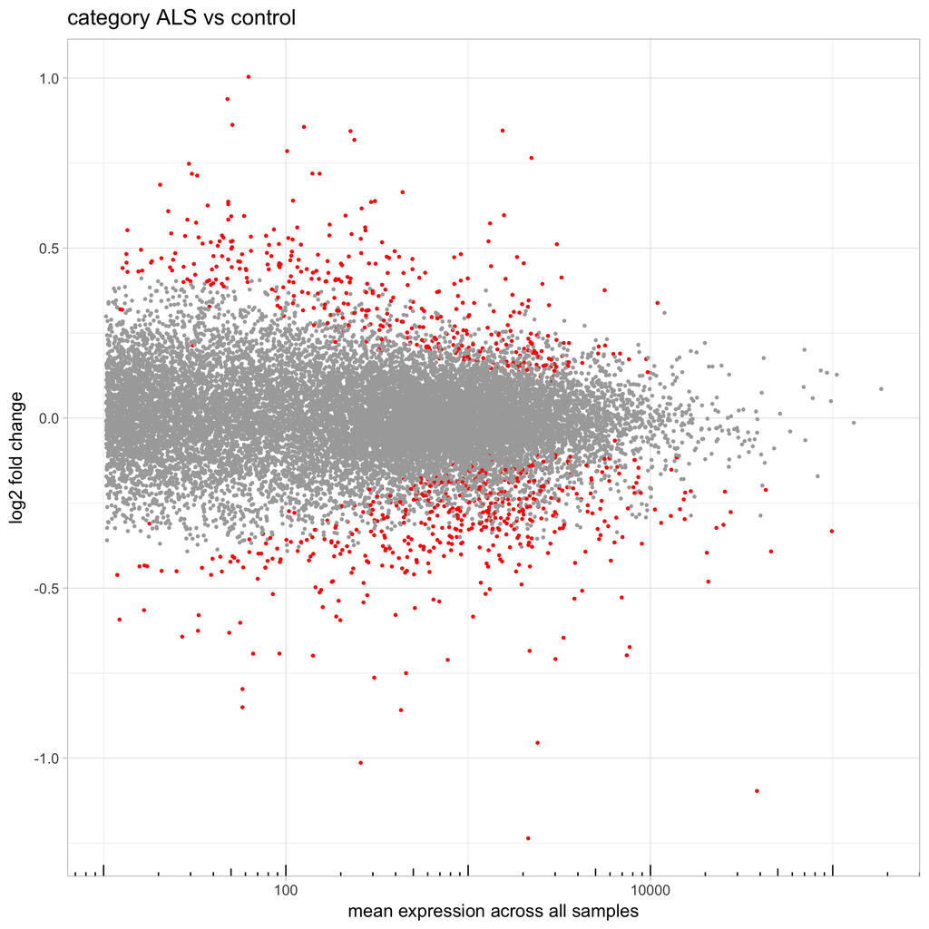

```r
> plotMA(res_shrunken)
```

```r
> markdownHeader("unshrunken", level = 3)
```

### unshrunken

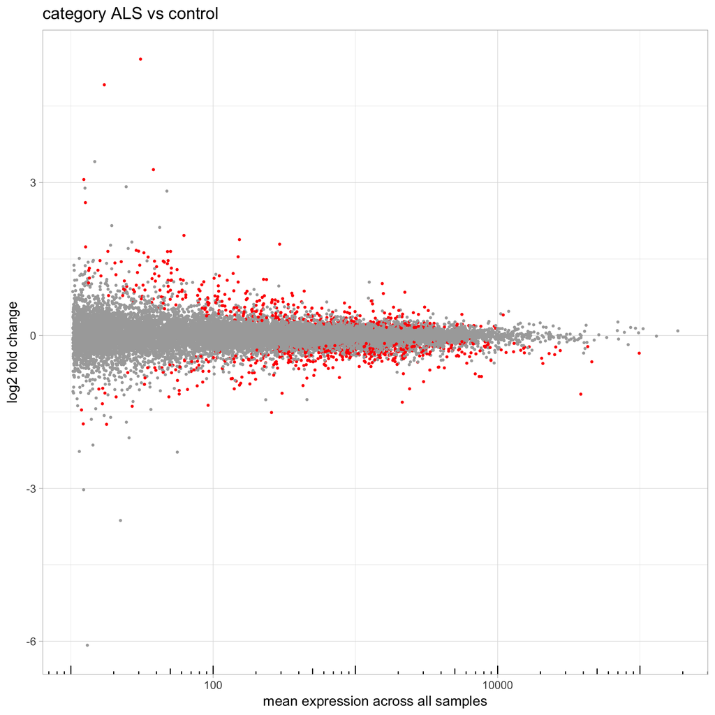

```r
> plotMA(res_unshrunken)
```

## Volcano

A volcano plot compares significance (BH-adjusted *P* value) against fold change (log2) (Cui and Churchill 2003; Li et al. 2014). Genes in the green box with text labels have an adjusted *P* value are likely to be the top candidate genes of interest.

```r
> markdownHeader("labeled", level = 3)
```

### labeled

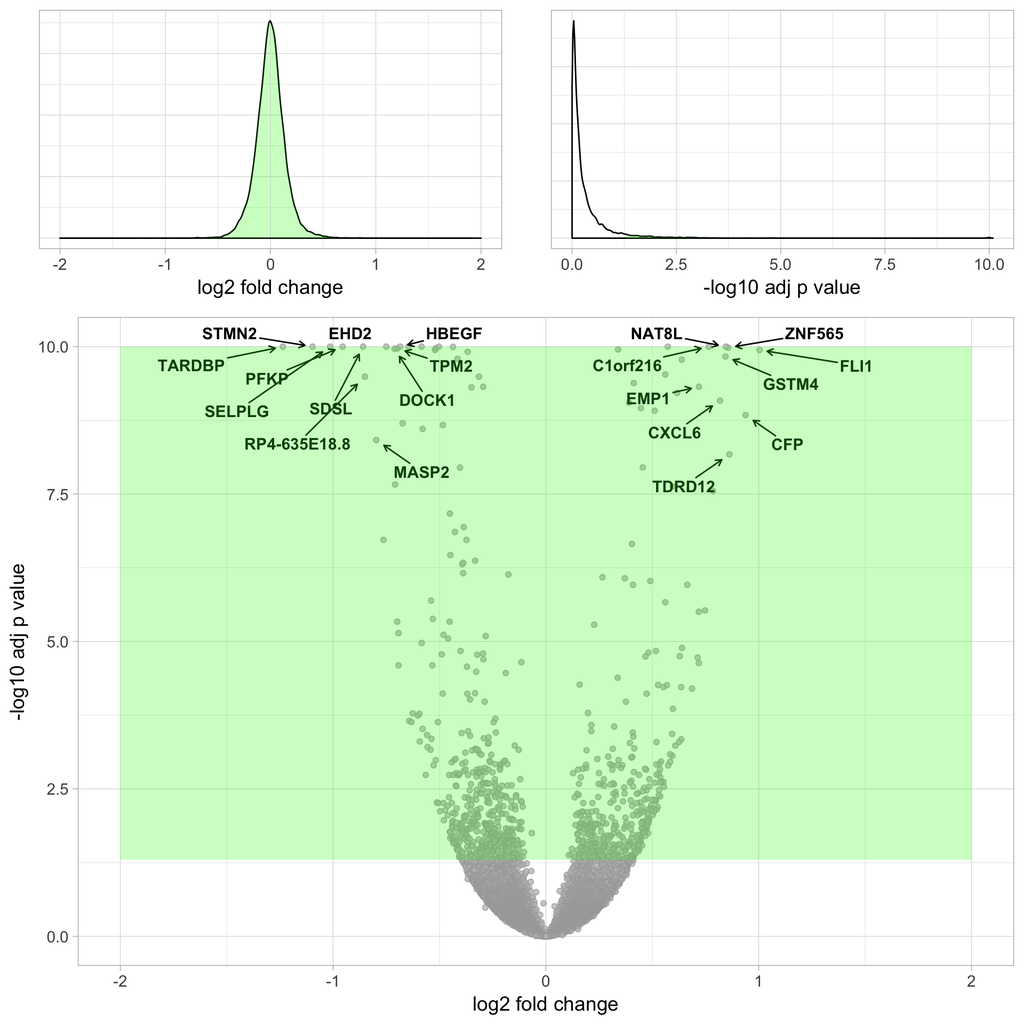

```r
> plotVolcano(res, lfc = params$lfc, gene2symbol = gene2symbol(bcb), ntop = 20,
+     histograms = TRUE)
```

## Heatmap

This plot shows only differentially expressed genes on a per-sample basis. We have scaled the data by row and used the `ward.D2` method for clustering (Ward 1963).

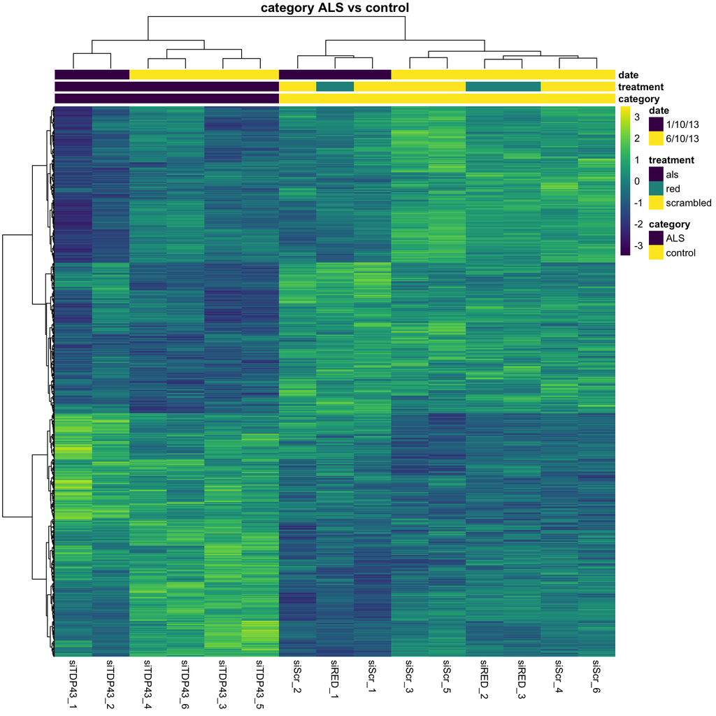

```r
> # help('pheatmap', 'pheatmap')
> annotation_col <- colData(dds) %>% .[, c("category", "treatment", "date"), drop = FALSE] %>%
+     as.data.frame()
> plotDEGHeatmap(res, counts = rld, gene2symbol = gene2symbol(bcb), annotationCol = annotation_col,
+     clustering_method = "ward.D2")
```

# DEG PCA plots

Now performing PCA using only our list of DEGs, we can see the samples are separating by treatment on PC1, which is good to see. The samples are separating on PC2 by date (batch), but that’s okay because we’ve taken that into account in our DESeq model for performing the differential expression. This looks good.

```r
> markdownHeader("category", level = 2)
```

## category

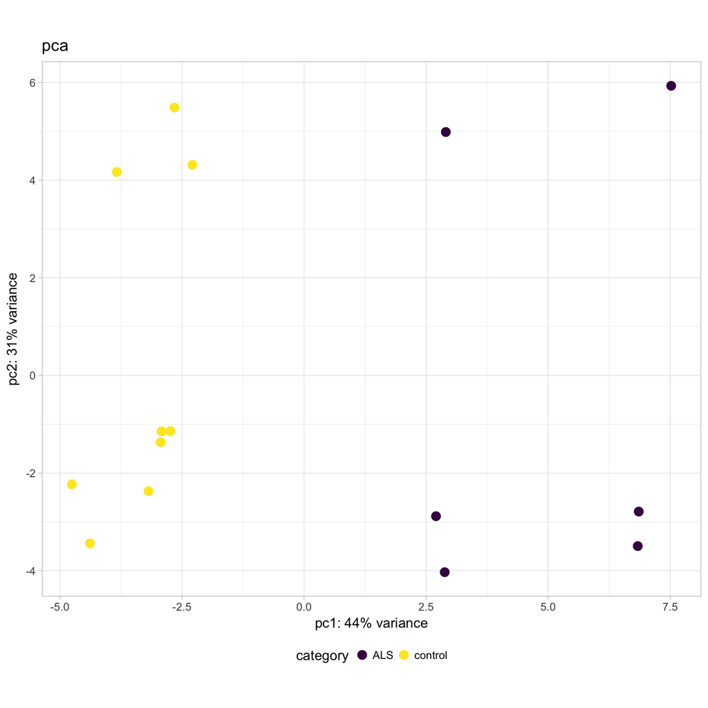

```r
> plotDEGPCA(res, counts = rld, interestingGroups = "category")
```

```r
> markdownHeader("date", level = 2)
```

## date

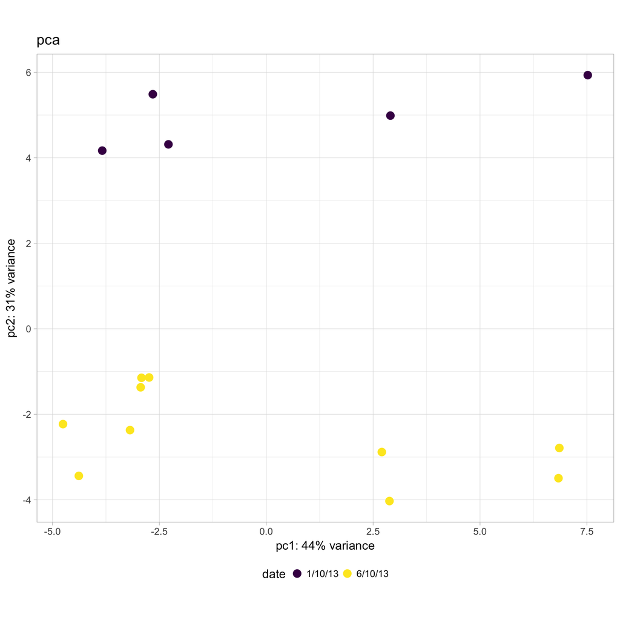

```r
> plotDEGPCA(res, counts = rld, interestingGroups = "date")
```

```r
> markdownHeader("category:date", level = 2)
```

## category:date

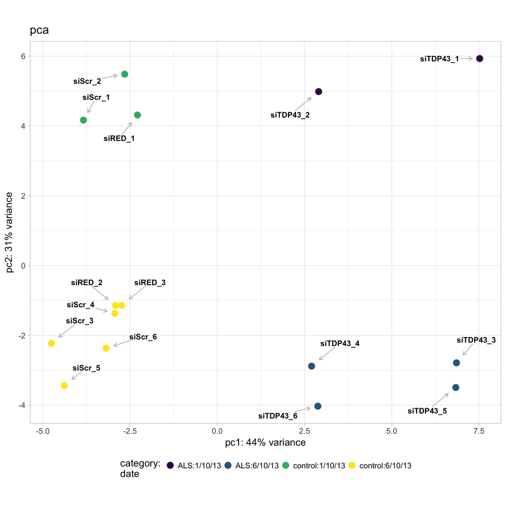

```r
> plotDEGPCA(res, counts = rld, interestingGroups = c("category", "date"), label = TRUE)
```

# Results tables

```r
> resTbl <- resultsTables(res, lfc = params$lfc, annotable = annotable(bcb), summary = TRUE,
+     headerLevel = 2, write = TRUE, dir = results_dir, dropboxDir = params$dropbox_dir)
```

## Results tables

- [`category_als_vs_control_all.csv.gz`](https://www.dropbox.com/s/hg4kdrwugc33ws5/category_als_vs_control_all.csv.gz?dl=0): All genes, sorted by Ensembl identifier.
- [`category_als_vs_control_deg.csv.gz`](https://www.dropbox.com/s/zgubmwzaoeq53hn/category_als_vs_control_deg.csv.gz?dl=0): Genes that pass the alpha (FDR) cutoff.
- [`category_als_vs_control_deg_lfc_up.csv.gz`](https://www.dropbox.com/s/stvd2jg0bt1so17/category_als_vs_control_deg_lfc_up.csv.gz?dl=0): Upregulated DEG; positive log2 fold change.
- [`category_als_vs_control_deg_lfc_down.csv.gz`](https://www.dropbox.com/s/u8zsauuy0s5gs3w/category_als_vs_control_deg_lfc_down.csv.gz?dl=0): Downregulated DEG; negative log2 fold change.

```r
> saveData(resTbl, dir = data_dir)
```

DEG tables are sorted by BH-adjusted P value, and contain the following columns:

- `ensgene`: [Ensembl](http://useast.ensembl.org) gene identifier.
- `baseMean`: Mean of the normalized counts per gene for all samples.
- `log2FoldChange`: log2 fold change.
- `lfcSE`: log2 standard error.
- `stat`: Wald statistic.
- `pvalue`: Walt test *P* value.
- `padj`: BH adjusted Wald test *P* value (corrected for multiple comparisons; aka FDR).
- `externalGeneName`: [Ensembl](http://useast.ensembl.org) name (a.k.a. symbol).
- `description`: [Ensembl](http://useast.ensembl.org) description.
- `geneBiotype`: [Ensembl](http://useast.ensembl.org) biotype (e.g. `protein_coding`).

## Top tables

```r
> topTables(resTbl)
```

category ALS vs control (upregulated)

| ensgene | baseMean | lfc | padj | symbol | description | biotype |
| --- | --- | --- | --- | --- | --- | --- |
| ENSG00000142686 | 2226 | 0.765 | 1.29e-18 | C1orf216 | chromosome 1 open reading frame 216 | protein_coding |
| ENSG00000185818 | 1544 | 0.845 | 8.87e-14 | NAT8L | N-acetyltransferase 8-like (GCN5-related, putative) | protein_coding |
| ENSG00000114648 | 1320 | 0.573 | 3.19e-13 | KLHL18 | kelch-like family member 18 | protein_coding |
| ENSG00000196357 | 126 | 0.856 | 4.35e-12 | ZNF565 | zinc finger protein 565 | protein_coding |
| ENSG00000111300 | 934 | 0.339 | 1.18e-11 | NAA25 | N(alpha)-acetyltransferase 25, NatB auxiliary subunit | protein_coding |
| ENSG00000151702 | 62 | 1.004 | 1.42e-11 | FLI1 | Fli-1 proto-oncogene, ETS transcription factor | protein_coding |
| ENSG00000168765 | 226 | 0.844 | 4.74e-11 | GSTM4 | glutathione S-transferase mu 4 | protein_coding |
| ENSG00000258839 | 308 | 0.638 | 6.68e-11 | MC1R | melanocortin 1 receptor (alpha melanocyte stimulating hormone receptor) | protein_coding |
| ENSG00000181449 | 272 | 0.561 | 1.97e-10 | SOX2 | SRY (sex determining region Y)-box 2 | protein_coding |
| ENSG00000180672 | 540 | 0.413 | 3.15e-10 | AC007362.1 | NA | pseudogene |
| ENSG00000134531 | 140 | 0.719 | 3.79e-10 | EMP1 | epithelial membrane protein 1 | protein_coding |
| ENSG00000137496 | 260 | 0.616 | 5.07e-10 | IL18BP | interleukin 18 binding protein | protein_coding |
| ENSG00000124875 | 237 | 0.818 | 7.25e-10 | CXCL6 | chemokine (C-X-C motif) ligand 6 | protein_coding |
| ENSG00000055147 | 466 | 0.391 | 7.95e-10 | FAM114A2 | family with sequence similarity 114, member A2 | protein_coding |
| ENSG00000134909 | 1335 | 0.447 | 1.01e-09 | ARHGAP32 | Rho GTPase activating protein 32 | protein_coding |
| ENSG00000072501 | 3065 | 0.511 | 1.12e-09 | SMC1A | structural maintenance of chromosomes 1A | protein_coding |
| ENSG00000126759 | 48 | 0.938 | 1.35e-09 | CFP | complement factor properdin | protein_coding |
| ENSG00000173809 | 51 | 0.862 | 6.63e-09 | TDRD12 | tudor domain containing 12 | protein_coding |
| ENSG00000146007 | 2018 | 0.455 | 1.11e-08 | ZMAT2 | zinc finger, matrin-type 2 | protein_coding |
| ENSG00000183778 | 212 | 0.595 | 2.35e-08 | B3GALT5 | UDP-Gal:betaGlcNAc beta 1,3-galactosyltransferase, polypeptide 5 | protein_coding |
| ENSG00000163739 | 102 | 0.785 | 2.80e-08 | CXCL1 | chemokine (C-X-C motif) ligand 1 (melanoma growth stimulating activity, alpha) | protein_coding |
| ENSG00000116455 | 911 | 0.404 | 2.21e-07 | WDR77 | WD repeat domain 77 | protein_coding |
| ENSG00000177542 | 1278 | 0.266 | 8.15e-07 | SLC25A22 | solute carrier family 25 (mitochondrial carrier: glutamate), member 22 | protein_coding |
| ENSG00000105202 | 676 | 0.371 | 8.49e-07 | FBL | fibrillarin | protein_coding |
| ENSG00000164932 | 395 | 0.491 | 9.43e-07 | CTHRC1 | collagen triple helix repeat containing 1 | protein_coding |
| ENSG00000176490 | 1603 | 0.409 | 1.09e-06 | DIRAS1 | DIRAS family, GTP-binding RAS-like 1 | protein_coding |
| ENSG00000213694 | 437 | 0.664 | 1.09e-06 | S1PR3 | sphingosine-1-phosphate receptor 3 | protein_coding |
| ENSG00000166819 | 115 | 0.560 | 2.16e-06 | PLIN1 | perilipin 1 | protein_coding |
| ENSG00000246877 | 29 | 0.748 | 2.98e-06 | DNM1P35 | DNM1 pseudogene 35 | antisense |
| ENSG00000108691 | 153 | 0.719 | 3.13e-06 | CCL2 | chemokine (C-C motif) ligand 2 | protein_coding |
| ENSG00000124789 | 1734 | 0.227 | 5.20e-06 | NUP153 | nucleoporin 153kDa | protein_coding |
| ENSG00000144452 | 109 | 0.639 | 1.29e-05 | ABCA12 | ATP-binding cassette, sub-family A (ABC1), member 12 | protein_coding |
| ENSG00000137070 | 337 | 0.517 | 1.45e-05 | IL11RA | interleukin 11 receptor, alpha | protein_coding |
| ENSG00000103404 | 912 | 0.482 | 1.54e-05 | USP31 | ubiquitin specific peptidase 31 | protein_coding |
| ENSG00000268798 | 48 | 0.629 | 1.77e-05 | AC027307.3 | Uncharacterized protein | protein_coding |
| ENSG00000180921 | 495 | 0.468 | 1.80e-05 | FAM83H | family with sequence similarity 83, member H | protein_coding |
| ENSG00000122877 | 33 | 0.713 | 1.87e-05 | EGR2 | early growth response 2 | protein_coding |
| ENSG00000205413 | 30 | 0.718 | 2.32e-05 | SAMD9 | sterile alpha motif domain containing 9 | protein_coding |
| ENSG00000261496 | 208 | 0.337 | 4.12e-05 | RP13-514E23.1 | NA | sense_overlapping |
| ENSG00000066135 | 2180 | 0.158 | 5.38e-05 | KDM4A | lysine (K)-specific demethylase 4A | protein_coding |
| ENSG00000178401 | 258 | 0.527 | 5.46e-05 | DNAJC22 | DnaJ (Hsp40) homolog, subfamily C, member 22 | protein_coding |
| ENSG00000168918 | 174 | 0.569 | 5.51e-05 | INPP5D | inositol polyphosphate-5-phosphatase, 145kDa | protein_coding |
| ENSG00000118503 | 273 | 0.552 | 5.93e-05 | TNFAIP3 | tumor necrosis factor, alpha-induced protein 3 | protein_coding |
| ENSG00000137673 | 293 | 0.635 | 5.93e-05 | MMP7 | matrix metallopeptidase 7 (matrilysin, uterine) | protein_coding |
| ENSG00000100985 | 20 | 0.686 | 6.31e-05 | MMP9 | matrix metallopeptidase 9 (gelatinase B, 92kDa gelatinase, 92kDa type IV collagenase) | protein_coding |
| ENSG00000164251 | 1854 | 0.474 | 7.69e-05 | F2RL1 | coagulation factor II (thrombin) receptor-like 1 | protein_coding |
| ENSG00000069275 | 5604 | 0.376 | 1.05e-04 | NUCKS1 | nuclear casein kinase and cyclin-dependent kinase substrate 1 | protein_coding |
| ENSG00000114270 | 1572 | 0.597 | 1.39e-04 | COL7A1 | collagen, type VII, alpha 1 | protein_coding |
| ENSG00000214022 | 2305 | 0.197 | 1.63e-04 | REPIN1 | replication initiator 1 | protein_coding |
| ENSG00000064393 | 5636 | 0.213 | 2.61e-04 | HIPK2 | homeodomain interacting protein kinase 2 | protein_coding |

category ALS vs control (downregulated)

| ensgene | baseMean | lfc | padj | symbol | description | biotype |
| --- | --- | --- | --- | --- | --- | --- |
| ENSG00000120948 | 2135 | -1.236 | 4.50e-87 | TARDBP | TAR DNA binding protein | protein_coding |
| ENSG00000104435 | 38398 | -1.097 | 1.55e-79 | STMN2 | stathmin-like 2 | protein_coding |
| ENSG00000067057 | 2404 | -0.955 | 2.47e-33 | PFKP | phosphofructokinase, platelet | protein_coding |
| ENSG00000159200 | 3335 | -0.646 | 1.54e-26 | RCAN1 | regulator of calcineurin 1 | protein_coding |
| ENSG00000177830 | 1064 | -0.584 | 6.18e-24 | CHID1 | chitinase domain containing 1 | protein_coding |
| ENSG00000139410 | 428 | -0.859 | 4.77e-19 | SDSL | serine dehydratase-like | protein_coding |
| ENSG00000024422 | 456 | -0.750 | 6.28e-17 | EHD2 | EH-domain containing 2 | protein_coding |
| ENSG00000113070 | 2174 | -0.685 | 1.82e-16 | HBEGF | heparin-binding EGF-like growth factor | protein_coding |
| ENSG00000110876 | 257 | -1.014 | 2.27e-13 | SELPLG | selectin P ligand | protein_coding |
| ENSG00000122642 | 1313 | -0.503 | 2.42e-13 | FKBP9 | FK506 binding protein 9, 63 kDa | protein_coding |
| ENSG00000198722 | 2182 | -0.436 | 7.84e-13 | UNC13B | unc-13 homolog B (C. elegans) | protein_coding |
| ENSG00000099901 | 1246 | -0.517 | 5.76e-12 | RANBP1 | RAN binding protein 1 | protein_coding |
| ENSG00000198467 | 7417 | -0.698 | 7.80e-12 | TPM2 | tropomyosin 2 (beta) | protein_coding |
| ENSG00000150760 | 772 | -0.711 | 8.75e-12 | DOCK1 | dedicator of cytokinesis 1 | protein_coding |
| ENSG00000068028 | 279 | -0.521 | 1.42e-11 | RASSF1 | Ras association (RalGDS/AF-6) domain family member 1 | protein_coding |
| ENSG00000028310 | 781 | -0.368 | 2.26e-11 | BRD9 | bromodomain containing 9 | protein_coding |
| ENSG00000152137 | 1498 | -0.415 | 6.14e-11 | HSPB8 | heat shock 22kDa protein 8 | protein_coding |
| ENSG00000181904 | 3360 | -0.315 | 2.23e-10 | C5orf24 | chromosome 5 open reading frame 24 | protein_coding |
| ENSG00000271895 | 58 | -0.851 | 2.23e-10 | RP4-635E18.8 | NA | antisense |
| ENSG00000125970 | 2519 | -0.295 | 3.79e-10 | RALY | RALY heterogeneous nuclear ribonucleoprotein | protein_coding |
| ENSG00000198420 | 7030 | -0.350 | 3.90e-10 | FAM115A | family with sequence similarity 115, member A | protein_coding |
| ENSG00000120937 | 7693 | -0.674 | 1.89e-09 | NPPB | natriuretic peptide B | protein_coding |
| ENSG00000179542 | 1173 | -0.484 | 2.03e-09 | SLITRK4 | SLIT and NTRK-like family, member 4 | protein_coding |
| ENSG00000169136 | 400 | -0.579 | 2.39e-09 | ATF5 | activating transcription factor 5 | protein_coding |
| ENSG00000009724 | 58 | -0.797 | 3.74e-09 | MASP2 | mannan-binding lectin serine peptidase 2 | protein_coding |
| ENSG00000155093 | 1479 | -0.404 | 1.12e-08 | PTPRN2 | protein tyrosine phosphatase, receptor type, N polypeptide 2 | protein_coding |
| ENSG00000166741 | 3015 | -0.709 | 2.17e-08 | NNMT | nicotinamide N-methyltransferase | protein_coding |
| ENSG00000123143 | 1831 | -0.451 | 6.77e-08 | PKN1 | protein kinase N1 | protein_coding |
| ENSG00000174943 | 568 | -0.386 | 1.15e-07 | KCTD13 | potassium channel tetramerization domain containing 13 | protein_coding |
| ENSG00000143367 | 1262 | -0.428 | 1.39e-07 | TUFT1 | tuftelin 1 | protein_coding |
| ENSG00000137507 | 305 | -0.764 | 1.89e-07 | LRRC32 | leucine rich repeat containing 32 | protein_coding |
| ENSG00000175426 | 2139 | -0.374 | 1.89e-07 | PCSK1 | proprotein convertase subtilisin/kexin type 1 | protein_coding |
| ENSG00000030110 | 461 | -0.449 | 3.43e-07 | BAK1 | BCL2-antagonist/killer 1 | protein_coding |
| ENSG00000167552 | 98853 | -0.333 | 4.27e-07 | TUBA1A | tubulin, alpha 1a | protein_coding |
| ENSG00000176697 | 806 | -0.389 | 4.64e-07 | BDNF | brain-derived neurotrophic factor | protein_coding |
| ENSG00000159176 | 4398 | -0.393 | 4.89e-07 | CSRP1 | cysteine and glycine-rich protein 1 | protein_coding |
| ENSG00000168397 | 1295 | -0.389 | 6.94e-07 | ATG4B | autophagy related 4B, cysteine peptidase | protein_coding |
| ENSG00000154978 | 1854 | -0.176 | 7.33e-07 | VOPP1 | vesicular, overexpressed in cancer, prosurvival protein 1 | protein_coding |
| ENSG00000164930 | 695 | -0.540 | 2.03e-06 | FZD6 | frizzled family receptor 6 | protein_coding |
| ENSG00000196361 | 3825 | -0.531 | 4.14e-06 | ELAVL3 | ELAV like neuron-specific RNA binding protein 3 | protein_coding |
| ENSG00000099625 | 614 | -0.453 | 4.62e-06 | C19orf26 | chromosome 19 open reading frame 26 | protein_coding |
| ENSG00000106631 | 141 | -0.699 | 4.62e-06 | MYL7 | myosin, light chain 7, regulatory | protein_coding |
| ENSG00000107738 | 66 | -0.693 | 7.22e-06 | C10orf54 | chromosome 10 open reading frame 54 | protein_coding |
| ENSG00000149591 | 20771 | -0.481 | 7.72e-06 | TAGLN | transgelin | protein_coding |
| ENSG00000115963 | 1674 | -0.283 | 8.10e-06 | RND3 | Rho family GTPase 3 | protein_coding |
| ENSG00000204116 | 504 | -0.460 | 8.92e-06 | CHIC1 | cysteine-rich hydrophobic domain 1 | protein_coding |
| ENSG00000143382 | 189 | -0.584 | 1.06e-05 | ADAMTSL4 | ADAMTS-like 4 | protein_coding |
| ENSG00000080503 | 914 | -0.401 | 1.45e-05 | SMARCA2 | SWI/SNF related, matrix associated, actin dependent regulator of chromatin, subfamily a, member 2 | protein_coding |
| ENSG00000143079 | 1648 | -0.295 | 1.60e-05 | CTTNBP2NL | CTTNBP2 N-terminal like | protein_coding |
| ENSG00000164742 | 1963 | -0.490 | 1.65e-05 | ADCY1 | adenylate cyclase 1 (brain) | protein_coding |

# Methods

RNA-seq counts were generated by [bcbio](https://github.com/chapmanb/bcbio-nextgen) and bcbioRNASeq using salmon (Patro et al. 2017). Counts were imported into [R](https://www.r-project.org) using [tximport](https://bioconductor.org/packages/release/bioc/html/tximport.html) (Soneson, Love, and Robinson 2016) and [DESeq2](https://bioconductor.org/packages/release/bioc/html/DESeq2.html) (Love, Huber, and Anders 2014). Gene annotations were obtained from [Ensembl](http://useast.ensembl.org). Plots were generated by [ggplot2](http://ggplot2.org) (Wickham 2009). Heatmaps were generated by [pheatmap](https://cran.r-project.org/web/packages/pheatmap/index.html) (Kolde 2015).

# R session information

```r
> mdHeader("YAML params", level = 2)
```

## YAML params

```r
> print(params)
```

```
## $bcb_file
## [1] "data/2018-02-20/bcb.rda"
##
## $design
## ~date + category
## <environment: 0x7fb0a5f8b8d0>
##
## $contrast
## [1] "category" "ALS"      "control"
##
## $alpha
## [1] 0.05
##
## $lfc
## [1] 0
##
## $output_dir
## [1] "."
##
## $dropbox_dir
## [1] "eggan-es_derived_motor_neuron_knockdown-rnaseq-human"
```

```r
> mdHeader("`devtools::session_info()`", level = 2)
```

## `devtools::session_info()`

```r
> devtools::session_info()
```

```
##  setting  value
##  version  R version 3.4.3 (2017-11-30)
##  system   x86_64, darwin15.6.0
##  ui       X11
##  language (EN)
##  collate  en_US.UTF-8
##  tz       America/New_York
##  date     2018-02-20
##
##  package                * version    date
##  acepack                  1.4.1      2016-10-29
##  affy                     1.56.0     2017-10-31
##  affyio                   1.48.0     2017-10-31
##  annotate                 1.56.1     2017-11-13
##  AnnotationDbi            1.40.0     2017-10-31
##  AnnotationFilter         1.2.0      2017-10-31
##  AnnotationHub            2.10.1     2017-11-08
##  assertive                0.3-5      2016-12-31
##  assertive.base           0.0-7      2016-12-30
##  assertive.code           0.0-1      2015-10-06
##  assertive.data           0.0-1      2015-10-06
##  assertive.data.uk        0.0-1      2015-10-06
##  assertive.data.us        0.0-1      2015-10-06
##  assertive.datetimes      0.0-2      2016-05-10
##  assertive.files          0.0-2      2016-05-10
##  assertive.matrices       0.0-1      2015-10-06
##  assertive.models         0.0-1      2015-10-06
##  assertive.numbers        0.0-2      2016-05-09
##  assertive.properties     0.0-4      2016-12-30
##  assertive.reflection     0.0-4      2016-12-30
##  assertive.sets           0.0-3      2016-12-30
##  assertive.strings        0.0-3      2016-05-10
##  assertive.types          0.0-3      2016-12-30
##  assertthat               0.2.0      2017-04-11
##  backports                1.1.2      2017-12-13
##  base                   * 3.4.3      2017-12-07
##  base64enc                0.1-3      2015-07-28
##  basejump                 0.3.1      2018-02-20
##  bcbioBase              * 0.1.4      2018-02-20
##  bcbioRNASeq            * 0.1.6      2018-02-20
```

[output cut: 157 more lines]

```
##  local
##  local
##  cran (@2.3)
##  cran (@0.9.5)
##  cran (@0.2.0)
##  CRAN (R 3.4.3)
##  cran (@0.6)
##  CRAN (R 3.4.3)
##  CRAN (R 3.4.3)
##  CRAN (R 3.4.3)
##  cran (@0.3.6)
##  CRAN (R 3.4.3)
##  cran (@1.3.5)
##  CRAN (R 3.4.1)
##  [ reached getOption("max.print") -- omitted 90 rows ]
```

```r
> mdHeader("`utils::sessionInfo()`", level = 2)
```

Benjamini, Yoav, and Yosef Hochberg. 1995. “Controlling the False Discovery Rate: A Practical and Powerful Approach to Multiple Testing.” *J. R. Stat. Soc. Series B Stat. Methodol.* 57 (1). [Royal Statistical Society, Wiley]: 289–300. http://www.jstor.org/stable/2346101.

Cui, Xiangqin, and Gary A Churchill. 2003. “Statistical Tests for Differential Expression in cDNA Microarray Experiments.” *Genome Biol.* 4 (4): 210. https://www.ncbi.nlm.nih.gov/pubmed/12702200.

Kolde, Raivo. 2015. *Pheatmap: Pretty Heatmaps*. https://CRAN.R-project.org/package=pheatmap.

Li, Wentian, Jan Freudenberg, Young Ju Suh, and Yaning Yang. 2014. “Using Volcano Plots and Regularized-Chi Statistics in Genetic Association Studies.” *Comput. Biol. Chem.* 48 (February): 77–83. doi:10.1016/j.compbiolchem.2013.02.003.

Love, Michael I, Wolfgang Huber, and Simon Anders. 2014. “Moderated Estimation of Fold Change and Dispersion for RNA-seq Data with DESeq2.” *Genome Biol.* 15 (12): 550. doi:10.1186/s13059-014-0550-8.

Patro, Rob, Geet Duggal, Michael I Love, Rafael A Irizarry, and Carl Kingsford. 2017. “Salmon Provides Fast and Bias-Aware Quantification of Transcript Expression.” *Nat. Methods* 14 (4): 417–19. doi:10.1038/nmeth.4197.

Soneson, Charlotte, Michael I Love, and Mark D Robinson. 2016. “Differential Analyses for RNA-seq: Transcript-Level Estimates Improve Gene-Level Inferences.” *F1000Res.* 4 (December). doi:10.12688/f1000research.7563.1.

Ward, Joe H, Jr. 1963. “Hierarchical Grouping to Optimize an Objective Function.” *Journal of the American Statistical Association* 58 (301). Taylor & Francis: 236–44. doi:10.1080/01621459.1963.10500845.

Wickham, Hadley. 2009. *Ggplot2: Elegant Graphics for Data Analysis*. Use R. Springer New York. doi:10.1007/978-0-387-98141-3.

Yang, Yee Hwa, Sandrine Dudoit, Percy Luu, David M Lin, Vivian Peng, John Ngai, and Terence P Speed. 2002. “Normalization for cDNA Microarray Data: A Robust Composite Method Addressing Single and Multiple Slide Systematic Variation.” *Nucleic Acids Res.* 30 (4): e15. https://www.ncbi.nlm.nih.gov/pubmed/11842121.